# Sampling Outcome

Xianbin Cheng

September 10, 2018

# Method

1. Load libraries and source R code.

```r
source("Sampling_libraries.R")
source("Sampling_plan.R")
source("Sampling_contamination.R")
source("Sampling_visualization.R")
```

2. List important parameters from `Sampling_contamination.R` and `Sampling_plan.R`.

**Contamination:**

- `n_sim` = the number of simulations
- `x_lim` = the limits of the horizontal axis
- `y_lim` = the limits of the vertical axis
- `x` = the horizontal coordinate of the contamination center, which follows a uniform distribution (`U(0,10)`)
- `y` = the vertical coordinate of the contamination center, which follows a uniform distribution(`U(0,10)`)

**Mode 1: Discrete Spread**

- `n_affected` = the number of affected plants near the contamination spot, which follows a Poisson distribution (`Pois(lambda = 5)`)
- `covar_mat` = covariance matrix of `x` and `y`, which defines the spread of contamination. Assume the spread follows a 2D normal distribution with var(X) = 0.25, var(Y) = 0.25 and cov(X, Y) = 0

**Mode 2: Continuous Spread**

- `spread_radius` = the radius of the contamination spread

**Sampling Plan:**

- `n_sp` = the number of sampling points
- `sp_radius` = the radius (m) of a circular region around the sample point. (Only applicable to **Mode 1: Discrete Spread**)

```r
## Contamination
n_sim = 3
x_lim = c(0, 10)
y_lim = c(0, 10)

### Mode 1
n_affected = rpois(n = 1, lambda = 5)
covar_mat = matrix(data = c(0.25, 0, 0, 0.25), nrow = 2, ncol = 2)

### Mode 2
spread_radius = 2.5

## Sampling plan
n_sp = 10
sp_radius = 1
```

```r
# Generate the coordinates of contamination points
contam_xy = sim_contam(n_sim = n_sim, x_lim = x_lim, y_lim = y_lim, covariance = covar_mat, n_affected = n_affected, radius = spread_radius)

# Generate the coordinates of sample points
sp_xy = sim_plan(n_sp = n_sp, x_lim = x_lim, y_lim = y_lim, r = sp_radius)

# Generate the combined coordinates of contamination and sample points
contam_sp_xy = rbind(contam_xy, sp_xy)
rownames(contam_sp_xy) = NULL
```

```r
summary(contam_sp_xy$label)
```

```
##         spot       spread sample point
##            3           11           10
```

```r
kable_styling(kable(subset(contam_sp_xy, select = -r), format = "html"), full_width = FALSE)
```

| X | Y | ID | label |
| --- | --- | --- | --- |
| 0.9685741 | 4.3261236 | 1-0 | spot |
| 2.9856226 | 0.2247456 | 2-0 | spot |
| 3.8556979 | 5.1816009 | 3-0 | spot |
| 1.4208607 | 4.2641689 | 1-1 | spread |
| 0.7998520 | 4.3741996 | 1-2 | spread |
| 1.1227763 | 4.5912777 | 1-4 | spread |
| 3.0840089 | 0.3280274 | 2-1 | spread |
| 3.1752646 | -0.9320890 | 2-2 | spread |
| 3.0442904 | -0.0213926 | 2-3 | spread |
| 2.2444955 | -0.2147365 | 2-4 | spread |
| 3.9027855 | 4.6134293 | 3-1 | spread |
| 3.3709349 | 5.6807729 | 3-2 | spread |
| 4.7991335 | 5.5529837 | 3-3 | spread |
| 3.2745884 | 4.8859314 | 3-4 | spread |
| 8.9011733 | 8.1294121 | sp-1 | sample point |
| 1.8924135 | 9.9652351 | sp-2 | sample point |
| 1.3374631 | 9.6326225 | sp-3 | sample point |
| 2.6245177 | 1.8398188 | sp-4 | sample point |
| 5.3594161 | 8.7150164 | sp-5 | sample point |
| 9.4361006 | 1.3845740 | sp-6 | sample point |
| 8.0978534 | 5.1389705 | sp-7 | sample point |
| 2.0156487 | 3.6078598 | sp-8 | sample point |
| 9.2018910 | 0.0363601 | sp-9 | sample point |
| 5.1497783 | 8.1997307 | sp-10 | sample point |

3. Calculate the Euclidean distance between sample points and contamination points.

```r
# Create a function that calculates the Euclidean distance between points and only outputs the distances between sample points and contamination points.
calc_dist = function(df){

  a = dist(x = df[ ,1:2], method = "euclidean") %>% as.matrix()

  sp_ind = which(df$label == "sample point")

  b = a[-sp_ind, sp_ind] %>%
    melt(data = ., varnames = c("row_contam", "row_sp"), value.name = "Distance")

  return(b)
}
```

```r
dist_contam_sp = calc_dist(contam_sp_xy)
```

4. Evaluate the performance of the sampling plan.

**Mode 1: Discrete Spread:**

- Determine which contamination points (spot and spread) are covered by sampling region with a radius of 1.

**Mode 2: Continuous Spread:**

- Determine which sample points are within the contamination region with a radius of 2.5.

```r
# Create a function to idenfity points that falls within a certain distance from another point
cover = function(df_dist, df_coord, r, method){

  ## Find the points that meet the distance criterion
  a = df_dist %>%
    filter(Distance <= r)

  ## Create columns that identify each observation
  contam_ID = df_coord$ID[a$row_contam]

  b = substr(x = contam_ID, start = 3, stop = 3)
  contam_type = ifelse(test = b == "0", yes = "spot", no = "spread")

  sp_ID = df_coord$ID[a$row_sp]

  c = cbind(a, contam_ID, sp_ID, contam_type)

  ## Create output based on the method.
  if(method == "discrete") {
    d = c %>%
      arrange(.data = ., contam_ID)
  } else if (method == "continuous") {
    d = c %>%
      dplyr::filter(contam_type == "spot") %>%
      arrange(.data = ., contam_ID)
  }

  return(d)
}

# Create a function that calculates the rate of detection
ROD = function(df_cover, df_contam, n_sp, method){
  if(method == "discrete"){
    length(unique(df_cover$contam_ID)) / nrow(df_contam)
  } else if (method == "continuous"){
    length(unique(df_cover$sp_ID)) / n_sp
  }
}
```

```r
# Mode 1: Discrete Spread
cover_dis = cover(df_dist = dist_contam_sp, df_coord = contam_sp_xy, r = sp_radius, method = "discrete")

# Mode 2: Continuous Spread
cover_cont = cover(df_dist = dist_contam_sp, df_coord = contam_sp_xy, r = spread_radius, method = "continuous")
```

# Results

1. **Mode 1: Discrete Spread**

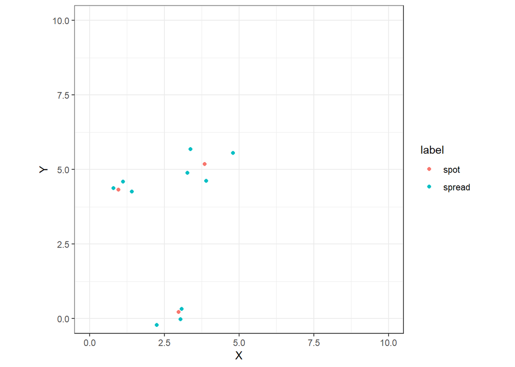

```r
# Discrete Spread
plot_contam_dis = contam_draw(data = contam_xy, method = "discrete", xlim = x_lim, ylim = y_lim)
plot_sp_dis = sp_draw(data = sp_xy, method = "discrete", xlim = x_lim, ylim = y_lim)
plot_overlay_dis = overlay_draw(data = contam_sp_xy, method = "discrete", xlim = x_lim, ylim = y_lim)

plot_contam_dis
```

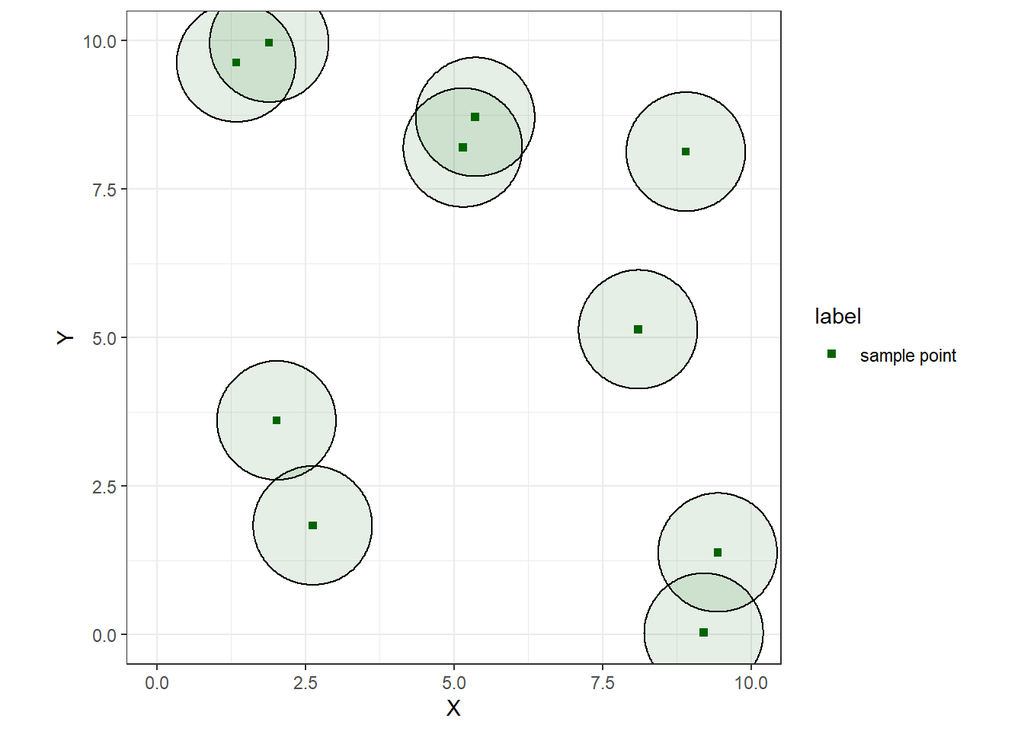

```r
plot_sp_dis
```

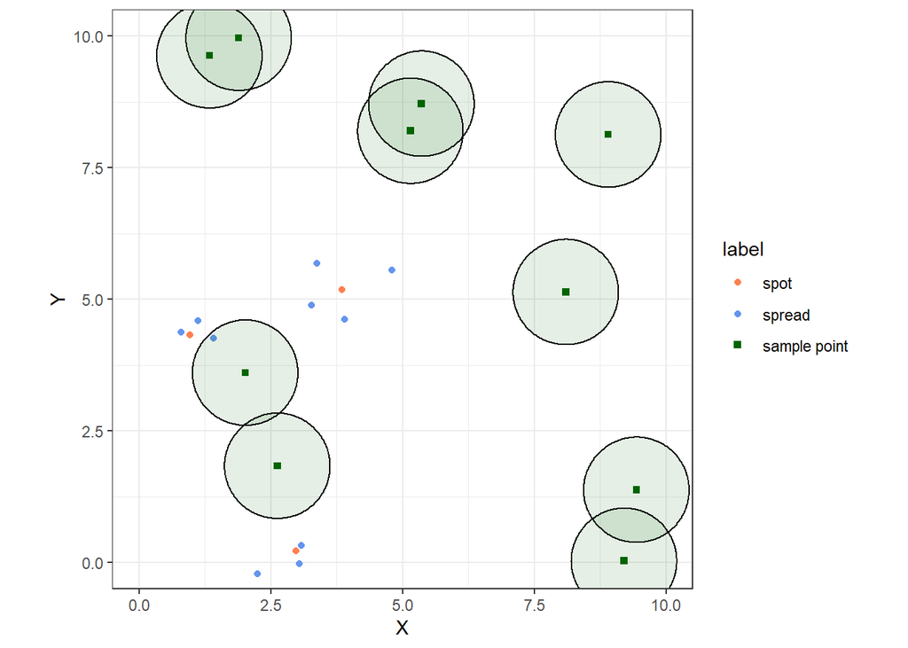

```r
plot_overlay_dis
```

```r
# Show the contamination points that are detected by sampling.
cover_dis %>%
  dplyr::select(-c(row_contam, row_sp))
```

```
##    Distance contam_ID sp_ID contam_type
## 1 0.8857282       1-1  sp-8      spread
```

```r
# Evaluation:
ROD(df_cover = cover_dis, df_contam = contam_xy, n_sp = n_sp, method = "discrete")
```

```
## [1] 0.07142857
```

- Therefore, we detected 1 out of 14 contamination points. The rate of detection is 0.0714286.
2. **Mode 2: Continuous Spread**

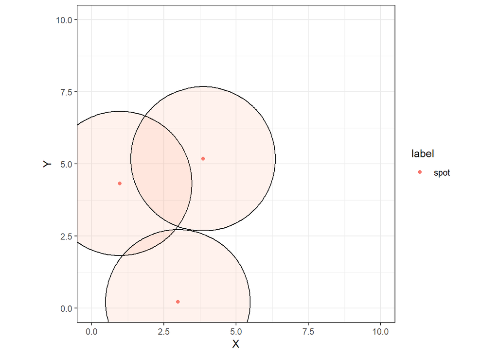

```r
# Continuous Spread
plot_contam_cont = contam_draw(data = contam_xy, method = "continuous", xlim = x_lim, ylim = y_lim)
plot_sp_cont = sp_draw(data = sp_xy, method = "continuous", xlim = x_lim, ylim = y_lim)
plot_overlay_cont = overlay_draw(data = contam_sp_xy, method = "continuous", xlim = x_lim, ylim = y_lim)

plot_contam_cont
```

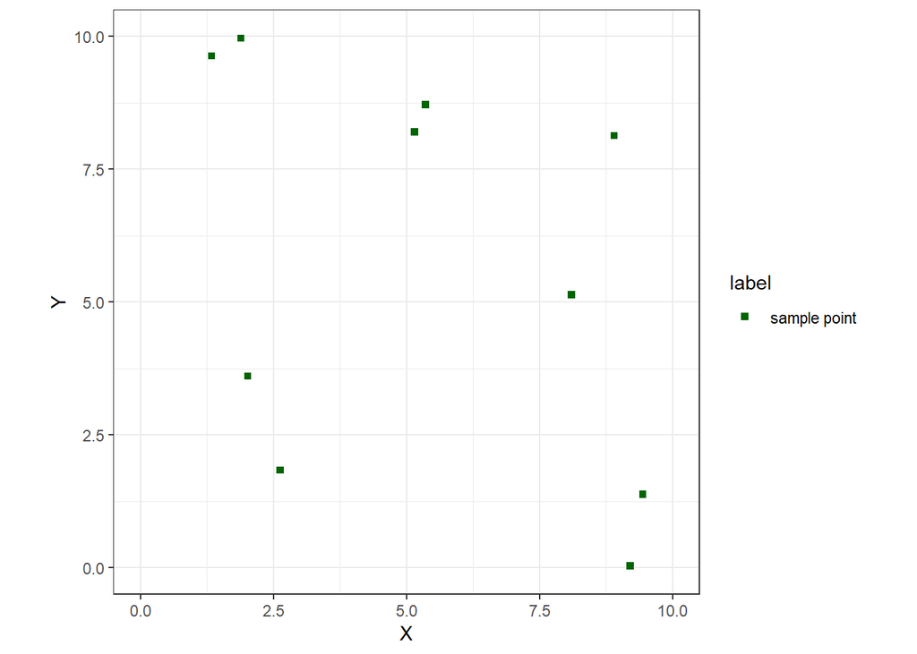

```r
plot_sp_cont
```

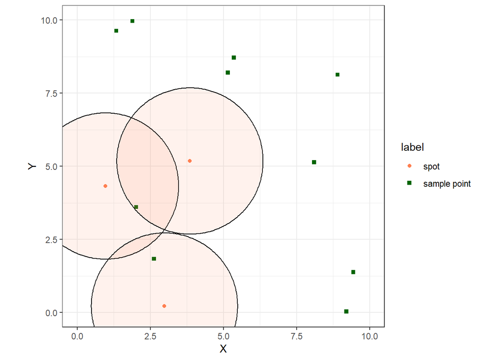

```r
plot_overlay_cont
```

```r
# Show the sample points that detected contamination
cover_cont %>%
  dplyr::select(-c(row_contam, row_sp))
```

```
##   Distance contam_ID sp_ID contam_type
## 1 1.269751       1-0  sp-8        spot
## 2 1.654950       2-0  sp-4        spot
## 3 2.421248       3-0  sp-8        spot
```

```r
# Evaluation:
ROD(df_cover = cover_cont, df_contam = contam_xy, n_sp = n_sp, method = "continuous")
```

```
## [1] 0.2
```

- Therefore, 2 out of 10 sample points detected contamination. The rate of detection is 0.2.

```r
pdf(file = "Sampling Plots.pdf")
  plot_contam_dis
  plot_sp_dis
  plot_overlay_dis
  plot_contam_cont
  plot_sp_cont
  plot_overlay_cont
dev.off()
```